# 특수한 확률분포

Sang Yeol Lee  
October 25 2017

## 함수산책 Part 5 스터디

### 수리통계학

- [페북 이벤트 링크](https://www.facebook.com/events/2034223026864267/)
- 스터디 자료는 구글드라이브 또는 github을 통해서 관리할 예정입니다.
  - [github 주소](https://github.com/KaggleBreak/analyticstool)
  - [스터디 구글드라이브](https://drive.google.com/drive/folders/0B2l0iH28o85xcHJRNWNUc1FvbEk)
  - 참고 서적 : [1] 수리통계학 실제와 응용(John E. Freund)

# 목차 (책 5,6장)

### 4.1 서론

### 4.2 이산형 균등분포

### 4.3 베르누이/이항 분포

### 4.4 기하분포와 음이항분포

### 4.5 초기하분포

### 4.6 포아송분포

### 4.7 다항분포

### 4.8 다변량 초기하분포

### 4.9 감마분포, 지수분포, 카이제곱분포

### 4.10 베타분포

### 4.11 정규분포

### 4.12 이변량 정규분포

### Reference

- [확률분포의 pmf, pdf 및 이에 대한 R function 정리](http://rstudio-pubs-static.s3.amazonaws.com/231148_1fc6fbca81b648159c86b490a40b4d4d.html) -[확률형 아이템을 위한 다항 분포](http://www.boxnwhis.kr/2015/06/04/multinomial_dist_for_gachas.html)

## 1.1 서론

- 각 분포에 대응하는 모수(parameters)
- 모수란 특정한 분포에서는 일정한 값을 갖되, 그 특정 분포와 같은 부류에 속한 다른 분포에 대해서는 다른 값을 가질 수 있음
- 모수를 구하기 위해서는 1. 정의에 직접 도출하여 구하는 방법, 2. 적률생성함수를 이용하여 구할 수 있음

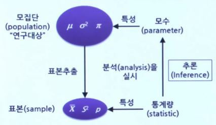

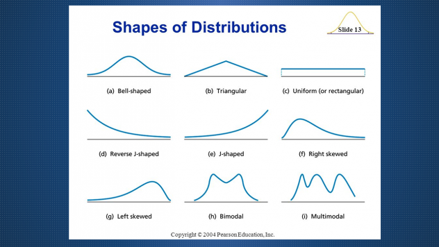

[적률과적률생성함수](https://m.blog.naver.com/PostView.nhn?blogId=mykepzzang&logNo=220846464280&proxyReferer=https%3A%2F%2Fwww.google.co.kr%2F)

[적률생성함수란 쉬운 버전](http://freshrimpsushi.tistory.com/248)

## 1-2 이산형 균등분포

\[ 매개변수 {\displaystyle a\in (\dots ,-2,-1,0,1,2,\dots )\,} {\displaystyle b\in (\dots ,-2,-1,0,1,2,\dots )\,} {\displaystyle n=b-a+1\,} \]

\[ 지지집합 {\displaystyle k\in \{a,a+1,\dots ,b-1,b\}\,} \]

\[ 확률 질량 {\displaystyle {\begin{matrix}{\frac {1}{n}}&{\mbox{for }}a\leq k\leq b\ \\0&{\mbox{otherwise }}\end{matrix}}} \]

\[ 기댓값 {\displaystyle {\frac {a+b}{2}}\,} \]

\[ 중앙값 {\displaystyle {\frac {a+b}{2}}\,} \]

\[ 분산 {\displaystyle {\frac {n^{2}-1}{12}}\,} \]

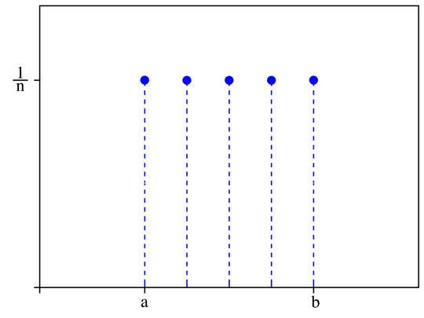

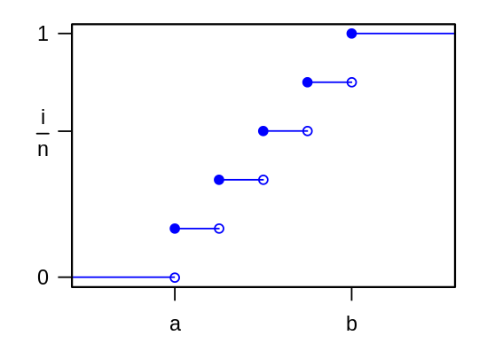

```r
library(extraDistr)
x <- rdunif(100, 0, 10)
x
```

```
  [1]  2 10  5  3  1  1  5  4  2  8  8  3  4  0  4  9  6 10  1  7  3  6  1
 [24]  8  0  3  9  5  6 10  4  4 10  8  5  6  2  8  4  0  6  0  6  0  0  9
 [47]  4  0  6 10  8  9 10  7  6  8 10 10  9  5  8  7  1  8  1  1 10  9 10
 [70]  6  4  0  5  2  9  8  3  6  5  6  8  5  6  8 10 10  5  3  1  5  5 10
 [93] 10  4  7  4  6  2  9  6
```

## 1-3 베르누이/이항 분포

### 1-3-1 베르누이 분포

- 베르누이 분포(Bernoulli Distribution)는 확률론과 통계학에서 매 시행마다 오직 두 가지의 가능한 결과만 일어난다고 할 때, 이러한 실험을 1회 시행하여 일어난 두 가지 결과에 의해 그 값이 각각 0과 1로 결정되는 확률변수 X에 대해서

\[ {\displaystyle P(X=0)=q}, {\displaystyle P(X=1)=p}, {\displaystyle 0\leq p\leq 1} , {\displaystyle q=1-p} \]

를 만족하는 확률변수 X가 따르는 확률분포를 의미하며, 이항 분포의 특수한 사례에 속한다.

### 1-3-2 이항 분포

[위키피디아 이항분포](https://ko.wikipedia.org/wiki/%EC%9D%B4%ED%95%AD_%EB%B6%84%ED%8F%AC)

- 이항 분포(二項分布)는 연속된 n번의 독립적 시행에서 각 시행이 확률 p를 가질 때의 이산 확률 분포이다. 이러한 시행은 베르누이 시행이라고 불리기도 한다. 사실, n=1일 때 이항 분포는 베르누이 분포이다. 이항 분포는 양봉 분포(Bimodal distribution)와는 다른 것이다.

\[ 매개변수 {\displaystyle n\geq 0} 시행 횟수 (정수) {\displaystyle 0\leq p\leq 1} 발생 확률 (실수) \]

\[ 확률 질량 {\displaystyle {n \choose k}p^{k}(1-p)^{n-k}\!} \]

\[ 누적 분포 {\displaystyle I_{1-p}(n-\lfloor k\rfloor ,1+\lfloor k\rfloor )\!} \]

\[ 기댓값 {\displaystyle np\!} \]

\[ 분산 {\displaystyle np(1-p)\!} \]

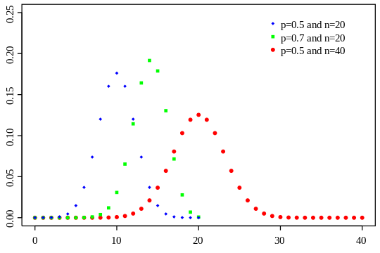

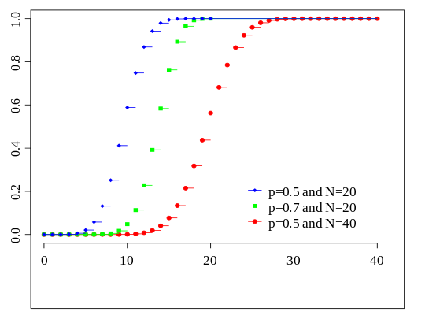

```r
dbinom(1, 1000, .001)
```

```
[1] 0.3680635
```

## 1-4 기하분포와 음이항분포

### 1-4-1 기하분포

- 독립적으로 시행되는 베르누이 시행 중 맨 처음 성공이 나올 때까지 반복하는 횟수를 확률변수로 둔 확률분포이다.
- k번째 시행에서 첫 번째 성공이 나올 확률을 계산하기 위해선 처음부터 k-1 번째 시행까지 실패이고 k번째에 시행에서 성공인 확률과 같음을 생각하면 편할 것이다. 따라서 확률질량함수가 위와 같아진다.

\[ p(k) = (1-p)^{k-1}p ~,~ k = 1, 2, 3, \cdots \cdots \]

```r
pgeom(1000, prob = .001)
```

```
[1] 0.6326723
```

- 1,000개의 확률형 아이템을 구매해서 아이템 A를 얻을 확률을 계산해보면 약 63%.

### 1-4-2 음이항 분포

- 기하분포는 첫 번째 성공이 나올 때 까지의 시행횟수 k에 대한 확률분포라 하면, 음이항 분포는 r번째 성공이 나올 때 까지의 시행횟수 k에 대한 확률분포이다. 따라서 음이항분포는 기하분포의 내용을 조금 더 일반화시킨 것으로 보면 이해가 편하다.

\[ p(k) = \binom{k-1}{r-1}(1-p)^{k-r}p^r ~,~ k = r, r+1, r+2, \cdots \cdots \]

```r
pnbinom(1000, 3, .001)
```

```
[1] 0.08076199
```

## 1-5 초기하분포

- 총 N개의 샘플은 M개의 원소로 이루어진 그룹1과 N-M개의 원소로 이루어진 그룹2로 구성되어 있다.
- 이때 N개 중 K개를 임의로 선택할 때 그룹1에서 나오는 원소의 수 k에 대한 확률분포를 의미한다.
- 옷장에는 옷이 총 10개가 있는데 상의가 7벌, 하의가 3벌로 이루어져 있다. 이때 내 옷장에서 임의로(simple random sampling) 3개의 옷을 집었을 때 상의가 2벌일 확률을 구하고 싶다면 이때 바로 초기하분포의 확률질량함수를 이용하면 되는 것이다.

\[ p(k) = \frac{\binom{M}{k} \binom{N-M}{K-k}}{\binom{N}{K}} \]

- 초기하분포에서 m→∞, n→∞, m/(m+n)→p이면 이항분포로 수렴한다. 마법 상자가 있어서 무한히 많은 사탕이 들어 있는데 딸기 맛이 60%, 겨자 맛이 40%로 비율이 일정한 경우 그 중 n개를 비복원 추출하는 경우를 생각해 보자.
- 무한히 사탕이 많으니 비복원 추출로 100개를 뽑으나 1억 개를 뽑으나 사탕 하나를 꺼낼 때 딸기 맛 사탕일 확률은 0.6이다.
- 그러니까 초기하분포가 모집단의 크기가 엄청나게 크면 이항분포에 가깝게 되는 것이다.

```r
rhyper(10, m = 7, n = 3, k = 3)
```

```
 [1] 2 2 1 2 2 2 1 2 2 1
```

## 1-6 포아송분포

[위키피디아 포아송분포](https://ko.wikipedia.org/wiki/%ED%91%B8%EC%95%84%EC%86%A1_%EB%B6%84%ED%8F%AC)

- 정해진 시간 안에 어떤 사건이 일어날 횟수에 대한 기댓값을 람다라고 했을 때, 그 사건이 n회 일어날 확률은 다음과 같다.
> 1. 어떤 단위구간(예, 1일)동안 이를 더 짧은 작은 단위의 구간(예 : 1시간)로 나눌 수 있고 이러한 더 짧은 단위구간 중에 어떤 사건이 발생할 확률은 전체 척도 중에서 항상 일정해야 한다.
> 2. 두 개 이상의 사건이 동시에 발생할 확률은 0에 가깝다.
> 3. 어떤 단위구간의 사건의 발생은 다른 단위구간의 발생으로부터 독립적이다.
> 4. 특정 구간에서의 사건 발생확률은 그 구간의 크기에 비례한다.
> 5. 푸아송분포 확률 변수의 기댓값과 분산은 모두 λ이다.

\[ 정의 {\displaystyle f(n;\lambda )={\frac {\lambda ^{n}e^{-\lambda }}{n!}},\,\!} {\displaystyle \mathrm {Poisson} (\lambda )} \]

\[ 매개변수 {\displaystyle \lambda >0}, 지지집합 0 이상의 정수 \]

\[ 누적 분포 {\displaystyle e^{-\lambda }\sum _{i=0}^{\lfloor k\rfloor }{\frac {\lambda ^{i}}{i!}}={\frac {\Gamma (\lfloor k+1\rfloor ,\lambda )}{\lfloor k\rfloor !}}} (이때 {\displaystyle \Gamma (x,y)} 는 불완전 감마 함수, {\displaystyle \lfloor x\rfloor } 는 바닥 함수) \]

- 이항분포를 따르는 위와 같은 확률변수 X에서, n이 대단히 크고 p가 대단히 작을 경우, 이 확률변수 X는 λ=np인 푸아송 분포로 근사할 수 있다.

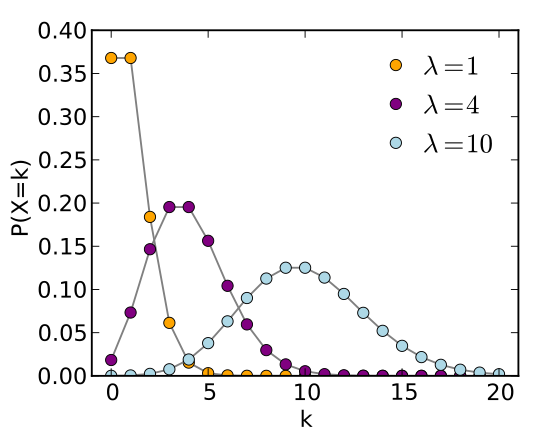

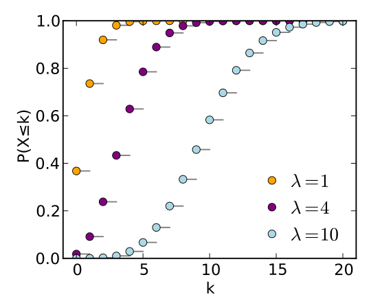

- 어느 은행의 1시간 당 방문 고객 수가 λ = 20 인 포아송 분포를 따른다고 한다. 그럼 1시간 당 방문고객수가 15명일 확률은?

```r
dpois(x=15, lambda = 20)
```

```
[1] 0.05164885
```

## 1-7 다항분포

[위키피디아 다항분포](https://ko.wikipedia.org/wiki/%EB%8B%A4%ED%95%AD_%EB%B6%84%ED%8F%AC)

- 다항 분포는 여러 개의 값을 가질 수 있는 독립 확률변수들에 대한 확률분포로, 여러 번의 독립적 시행에서 각각의 값이 특정 횟수가 나타날 확률을 정의한다.
- 다항 분포에서 차원이 2인 경우 이항 분포가 된다

\[ 기호 {\displaystyle \mathrm {Multinomial} } \]

\[ 매개변수 {\displaystyle n} : 자연수, {\displaystyle (p_{1},\cdots ,p_{n})} : 합이 1인 양의 실수들 \]

\[ 지지집합 {\displaystyle X_{i}} : 0부터 n까지의 정수, {\displaystyle \sum _{i}X_{i}=n} \]

\[ 확률 질량 {\displaystyle {\frac {n!}{x_{1}!\cdots x_{k}!}}p_{1}^{x_{1}}\cdots p_{k}^{x_{k}}} \]

\[ 기댓값 {\displaystyle E\{X_{i}\}=np_{i}} \]

\[ 분산 {\displaystyle \textstyle {\mathrm {Var} }(X_{i})=np_{i}(1-p_{i})} \]

| A | B | C | D | E | F | G | H | I | total |
| --- | --- | --- | --- | --- | --- | --- | --- | --- | --- |
| 0 | 7 | 35 | 50 | 112 | 106 | 183 | 208 | 299 | 1,000 |

```r
dmultinom(c(0, 7, 35, 50, 112, 106, 183, 208, 299), prob=c(.001, .005, .034, .05, .1, .12, .19, .2, .3))
```

```
[1] 4.986008e-11
```

| A | B | others | total |
| --- | --- | --- | --- |
| 0 | 7 | 993 | 1,000 |

```r
dmultinom(c(0, 7, 993), prob=c(.001, .005, .994))
```

```
[1] 0.03853889
```

- 즉, 확률형 아이템을 1,000개 구매하여 아이템 A는 0개, 아이템 B는 7개 얻을 확률은 약 3.85%다. 나머지 아이템을 몇 개 얻는지는 큰 관심이 없다.

## 1-8 다변량 초기하분포

- 서로 다른 특성 A1, A2, …, Ak를 갖는 품목이 각각 r1, r2, …, rk개씩 들어 있는 용기에서 n개를 추출할 때, 각 특성을 가진 품목이 각각 X1, X2, …, Xk인 확률분포

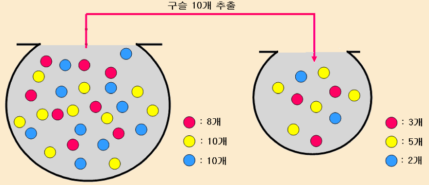

## 1-9 감마분포, 지수분포, 카이제곱분포 [1]

[위키피디아 감마분포](https://ko.wikipedia.org/wiki/%EA%B0%90%EB%A7%88_%EB%B6%84%ED%8F%AC)

- 감마 분포는 연속 확률분포로, 두 개의 매개변수를 받으며 양의 실수를 가질 수 있다.
- 감마 분포는 지수 분포나 푸아송 분포 등의 매개변수에 대한 켤레 사전 확률 분포이며, 이에 따라 베이즈 확률론에서 사전 확률 분포로 사용된다.
> 1. 매개변수 k가 정수인 경우 감마 분포는 얼랑 분포가 된다.
> 2. k=1,theta=1/lamda 는 지수 분포가 된다.
> 3. k=nu/2, theta=2는 카이제곱 분포가 된다. 이때 자유도는 nu이다.

\[ f(x) = \frac{\lambda^{\alpha}}{\Gamma(\alpha)}x^{\alpha-1}e^{-\lambda x} ~,~ x \ge 0 \]

\[ 매개변수 {\displaystyle k>0\,} 모양 (실수) , {\displaystyle \theta >0\,} 크기 (실수) \]

\[ 지지집합 {\displaystyle x\in [0;\infty )\!} \]

\[ 확률 밀도 {\displaystyle x^{k-1}{\frac {\exp \left(-x/\theta \right)}{\Gamma (k)\,\theta ^{k}}}} \]

\[ 누적 분포 {\displaystyle {\frac {\gamma (k,x/\theta )}{\Gamma (k)}}} \]

\[ 기댓값 {\displaystyle k\theta \,}, 분산 {\displaystyle k\theta ^{2}\,} \]

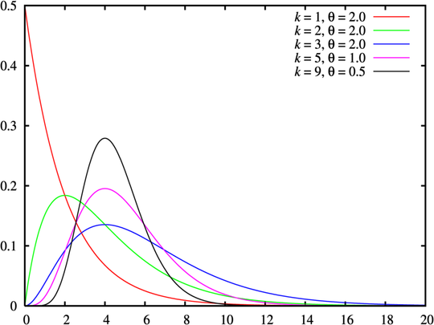

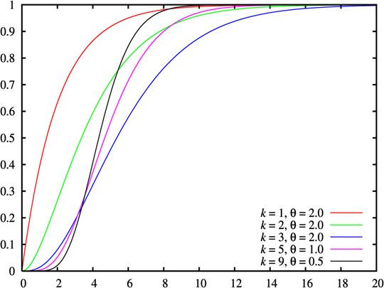

## 1-9 감마분포, 지수분포, 카이제곱분포 [2]

```r
dgamma(1, shape = 1, rate = 3)
```

```
[1] 0.1493612
```

[위키피디아 지수분포](https://ko.wikipedia.org/wiki/%EC%A7%80%EC%88%98%EB%B6%84%ED%8F%AC)

- 확률론과 통계학에서, 지수분포(指數分布, 영어: exponential distribution)는 연속 확률 분포의 일종이다.
- 사건이 서로 독립적일 때, 일정 시간동안 발생하는 사건의 횟수가 푸아송 분포를 따른다면, 다음 사건이 일어날 때까지 대기 시간은 지수분포를 따른다.
- 이산형 확률분포인 기하분포를 연속형에 적용한 것으로 볼 수 있다. 기하분포는 첫 번째 성공 사건이 일어날 때까지의 시행횟수에 대한 확률분포이면, 지수분포는 첫 번째 성공 사건이 일어날 때까지의 대기시간에 대한 확률분포로 볼 수 있다.

\[ 기호 {\displaystyle {\mbox{Exponential(}}\lambda {\mbox{) or Exp(}}\lambda {\mbox{)}}} \]

\[ 매개변수 {\displaystyle \lambda >0} : 빈도 \]

\[ 지지집합 {\displaystyle x\in [0,\infty )} \]

\[ 확률 밀도 {\displaystyle \lambda e^{-\lambda x}} \]

\[ 누적 분포 {\displaystyle 1-e^{-\lambda x}} \]

\[ 기댓값 {\displaystyle {\frac {1}{\lambda }}} \]

\[ 분산 {\displaystyle {\frac {1}{\lambda ^{2}}}} \]

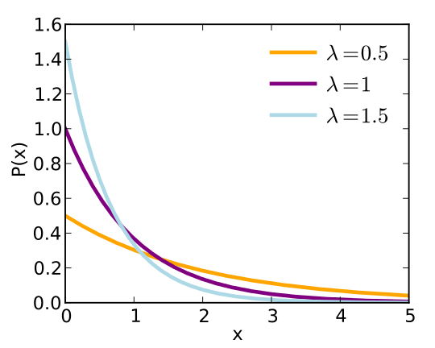

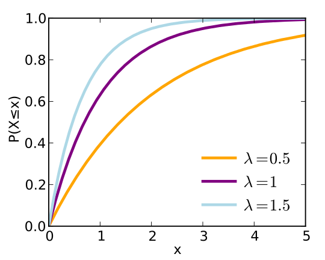

```r
dexp(1, rate = 3)
```

```
[1] 0.1493612
```

## 1-9 감마분포, 지수분포, 카이제곱분포 [3]

[위키피디아 카이제곱분포](https://ko.wikipedia.org/wiki/%EC%B9%B4%EC%9D%B4%EC%A0%9C%EA%B3%B1_%EB%B6%84%ED%8F%AC)

- 카이제곱 분포, χ2 분포(χ제곱分布, 영어: chi-squared distribution)는 k개의 서로 독립적인 표준정규 확률변수를 각각 제곱한 다음 합해서 얻어지는 분포이다.
- 이 때 k를 자유도라고 하며, 카이제곱 분포의 매개변수가 된다. 카이제곱 분포는 신뢰구간이나 가설검정 등의 모델에서 자주 등장한다.

\[ 매개변수 자연수 {\displaystyle k} : 자유도 \] \[ 지지집합 x ∈ [0, +∞) \] \[ 확률 밀도 {\displaystyle {\frac {1}{2^{k/2}\Gamma (k/2)}}\;x^{k/2-1}e^{-x/2}} \]

\[ 누적 분포 {\displaystyle {\frac {1}{\Gamma (k/2)}}\;\gamma (k/2,\,x/2)} \]

\[ 기댓값 {\displaystyle k}, 분산 {\displaystyle 2k} \]

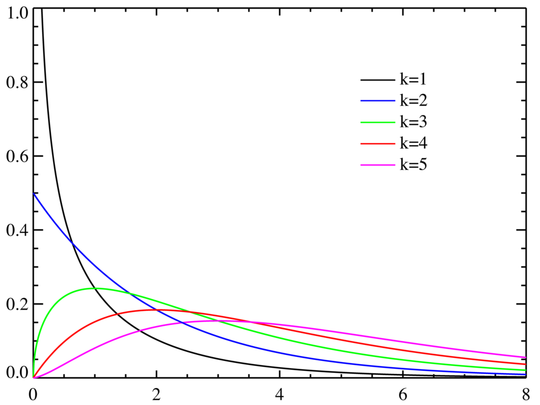

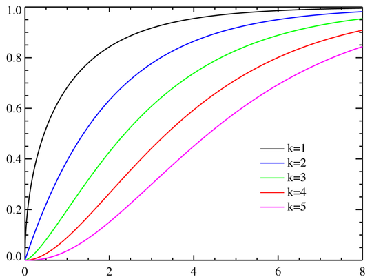

```r
pchisq(2, df = 10)
```

```
[1] 0.003659847
```

[figure not shown]

```r
x <-  matrix(c(324,371.28,78,79.56,261,212.16), nrow=2,
      dimnames = list(c("관찰", "기대"), c("제품A", "제품B", "제품C")))

barplot(x, beside = TRUE, legend = TRUE)
```

```r
chisq.test(x = x[c(1),], p = c(0.56, 0.12, 0.32))
```

```
    Chi-squared test for given probabilities

data:  x[c(1), ]
X-squared = 17.295, df = 2, p-value = 0.0001756
```

## 1-10 베타 분포

[위키피디아 베타분포](https://ko.wikipedia.org/wiki/%EB%B2%A0%ED%83%80_%EB%B6%84%ED%8F%AC)

- 확률론과 통계학에서, 베타 분포(Β分布, 영어: beta distribution)는 두 매개변수 alpha 와 beta에 따라 [0,1] 구간에서 정의되는 연속 확률 분포들의 가족이다

\[ f(x) = \frac{\Gamma(\alpha + \beta)}{\Gamma(\alpha) \Gamma(\beta)}x^{\alpha-1}(1-x)^{\beta-1} ~,~ 0 \le x \le 1 \]

기호 Beta(α, β) 매개변수 α,β > 0

\[ 지지집합 {\displaystyle x\in [0,1]} \]

\[ 확률 밀도 {\displaystyle {\frac {x^{\alpha -1}(1-x)^{\beta -1}}{\mathrm {B} (\alpha ,\beta )}}} \]

\[ 누적 분포 {\displaystyle I_{x}(\alpha ,\beta )} \]

\[ 기댓값 {\displaystyle \operatorname {E} [X]={\frac {\alpha }{\alpha +\beta }}\!}, {\displaystyle \operatorname {E} [\ln X]=\psi (\alpha )-\psi (\alpha +\beta )} \]

\[ 분산 {\displaystyle \operatorname {var} [X]={\frac {\alpha \beta }{(\alpha +\beta )^{2}(\alpha +\beta +1)}}} {\displaystyle \operatorname {var} [\ln X]=\psi _{1}(\alpha )-\psi _{1}(\alpha +\beta )} (폴리감마함수) \]

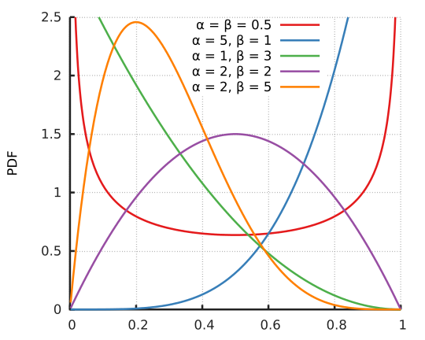

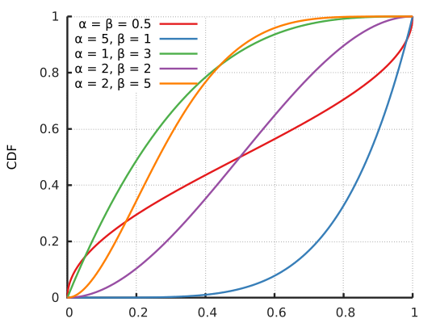

```r
dbeta(.5, shape1 = 2, shape2 = 3)
```

```
[1] 1.5
```

## 1-11 정규 분포

[위키피디아 정규분포](https://ko.wikipedia.org/wiki/%EC%A0%95%EA%B7%9C%EB%B6%84%ED%8F%AC)

- 확률론과 통계학에서, 정규분포(正規分布, 영어: normal distribution) 또는 가우스 분포(Gauß分布, 영어: Gaussian distribution)는 연속 확률 분포의 하나이다. 정규분포는 수집된 자료의 분포를 근사하는 데에 자주 사용되며, 이것은 중심극한정리에 의하여 독립적인 확률변수들의 평균은 정규분포에 가까워지는 성질이 있기 때문이다.
- 정규분포는 2개의 매개 변수 평균과 표준편차에 대해 모양이 결정되고, 이때의 분포를 N(mu,sigma)로 표기한다. 특히, 평균이 0이고 표준편차가 1인 정규분포 N (0,1)을 표준정규분포(standard normal distribution)라고 한다.

\[ 매개변수 {\displaystyle \mu } \]

\[ 평균 {\displaystyle \sigma ^{2}>0} 분산 \]

\[ 지지집합 {\displaystyle x\in (-\infty ;+\infty )\!} \]

\[ 확률 밀도 {\displaystyle {\frac {1}{\sigma {\sqrt {2\pi }}}}\;\exp \left(-{\frac {\left(x-\mu \right)^{2}}{2\sigma ^{2}}}\right)\!} \]

\[ 누적 분포 {\displaystyle {\frac {1}{2}}\left(1+\mathrm {erf} \,{\frac {x-\mu }{\sigma {\sqrt {2}}}}\right)\!} \]

\[ 기댓값 {\displaystyle \mu } \]

\[ 분산 {\displaystyle \sigma ^{2}} \]

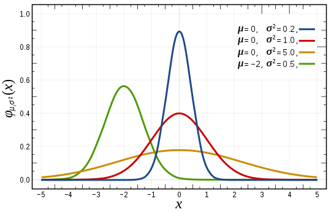

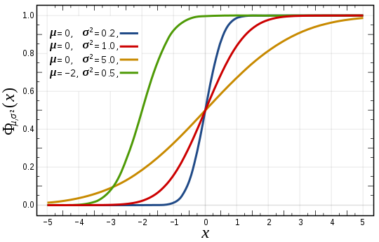

```r
dnorm(0, mean = 0, sd = 1)
```

```
[1] 0.3989423
```